# ggplot2

## Extra plotting with ggplot2

ggplot2 is an great package for making pretty plots.

This notebook will only descripe ggplot2 very shortly, as there are other excellent resources descibing the details:

- [The Cookbook - Comprehensive collection with detailed information](http://www.cookbook-r.com/Graphs/)
- [The R graph gallery - All the visualizations you can think of (ggplot2 and more)](https://www.r-graph-gallery.com/)
- 4 hour ggplot2 webinar - [Part 1](https://www.youtube.com/watch?v=h29g21z0a68) and [Part 2](https://www.youtube.com/watch?v=0m4yywqNPVY)

**Cheatsheet - 2-page pdf with a summary of ggplot2:**

[figure not shown]

```r
# Load ggplot2
library(ggplot2)
```

```r
# Data
data(mtcars)
```

## ggplot2 components

The backbone is created with the ggplot function, where we input our data.frame:

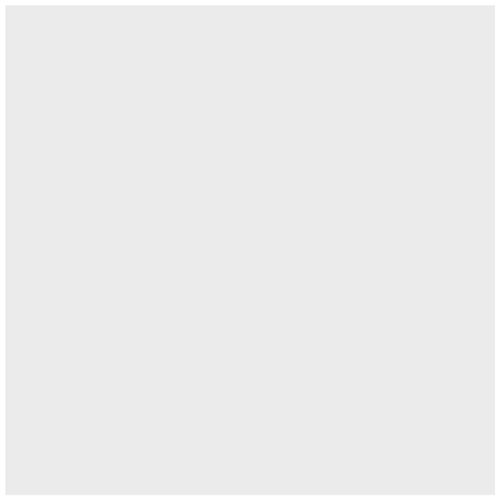

```r
ggplot(mtcars)
```

### Aesthetics

Usually we would also add the aesthetics (aes), which tells which variables should be on the x-axes, on the y-axis, and if any variables should be used to indicate color, shape, or linetype.

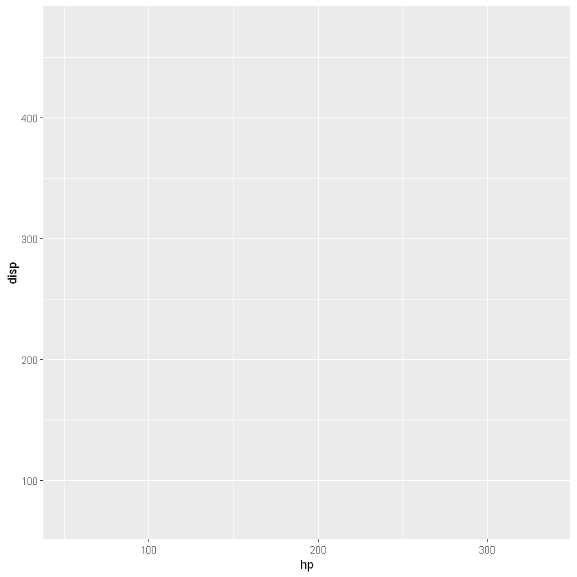

```r
ggplot(mtcars, aes(x = hp, y = disp, color = gear))
```

### Geometrics

This however does not draw the plot. We need to add geometrics (geom), which tells ggplot2 how to plot the data:

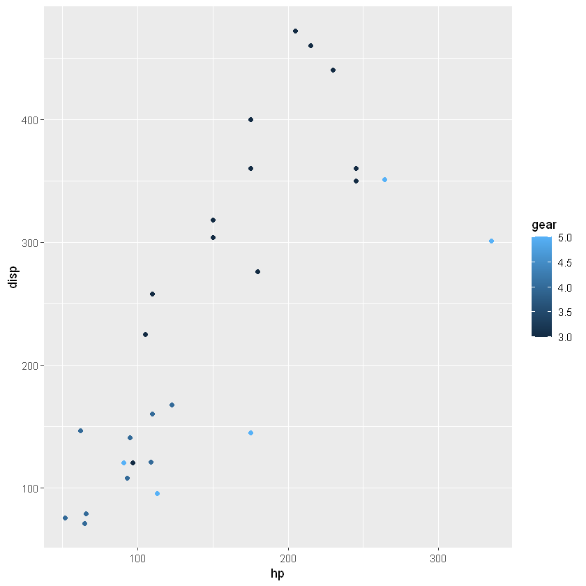

```r
ggplot(mtcars, aes(x = hp, y = disp, color = gear)) +
    geom_point()
```

### Themes

We can then add a theme:

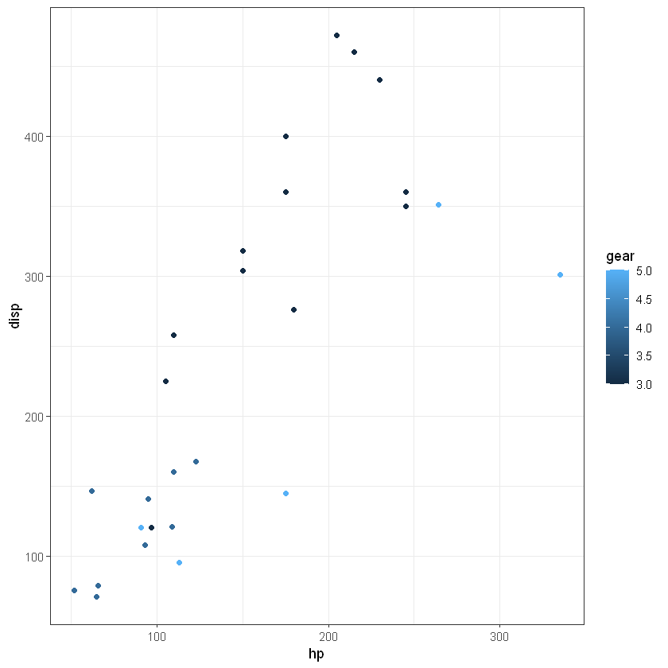

```r
ggplot(mtcars, aes(x = hp, y = disp, color = gear)) +
    geom_point() +
    theme_bw()
```

### Scales

We can add scales:

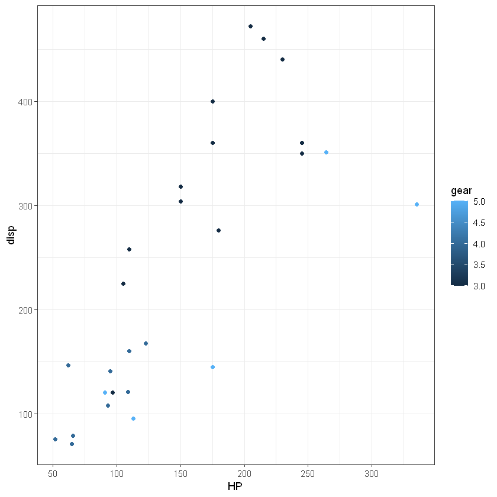

```r
ggplot(mtcars, aes(x = hp, y = disp, color = gear)) +
    geom_point() +
    theme_bw() +
    scale_x_continuous(name="HP", breaks=seq(0,350,50))
```

### Labels

We can add labels:

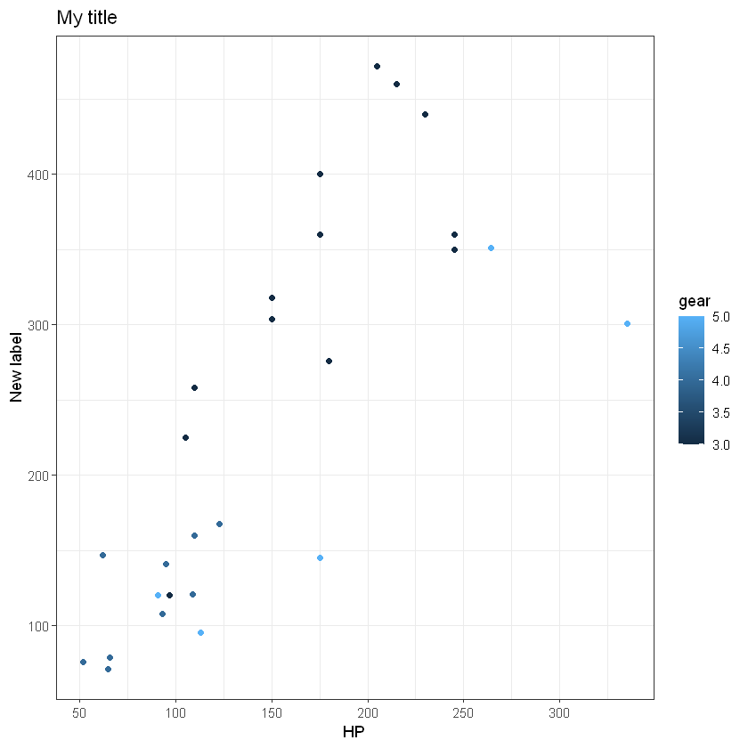

```r
ggplot(mtcars, aes(x = hp, y = disp, color = gear)) +
    geom_point() +
    theme_bw() +
    scale_x_continuous(name="HP", breaks=seq(0,350,50)) +
    ylab("New label") +
    ggtitle("My title")
```

### Facetting

We can facet the plot, by splitting it by a variable:

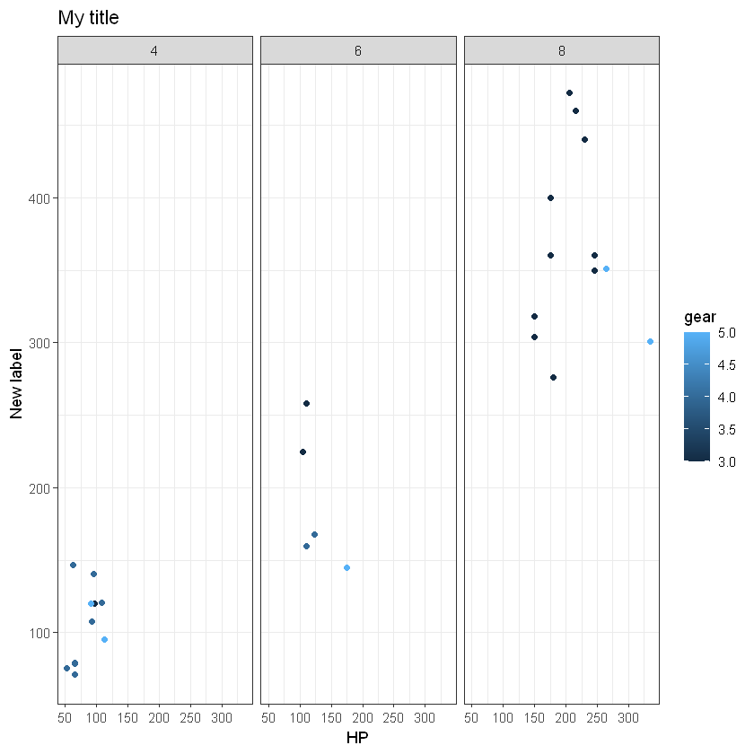

```r
ggplot(mtcars, aes(x = hp, y = disp, color = gear)) +
    geom_point() +
    theme_bw() +
    scale_x_continuous(name="HP", breaks=seq(0,350,50)) +
    ylab("New label") +
    ggtitle("My title") +
    facet_grid(.~cyl)
```

### Regressions

We can add a linear regression:

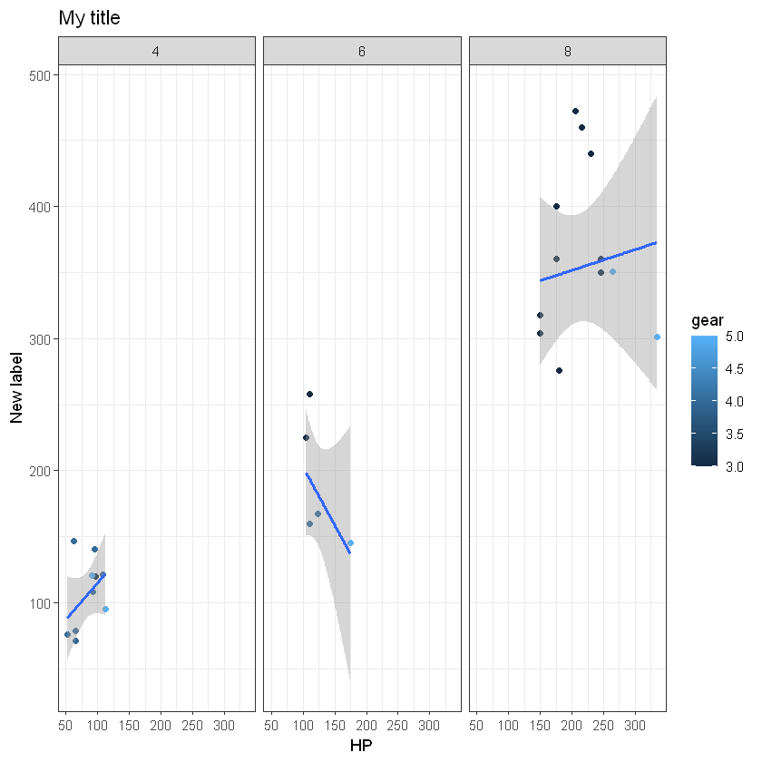

```r
ggplot(mtcars, aes(x = hp, y = disp, color = gear)) +
    geom_point() +
    theme_bw() +
    scale_x_continuous(name="HP", breaks=seq(0,350,50)) +
    ylab("New label") +
    ggtitle("My title") +
    facet_grid(.~cyl) +
    stat_smooth(method = "lm")
```